# Applied Researcher Experiment

IR Literature

Adeline Lo, Kyler Hudson, & Devin Judge-Lord

# 1 Network Creation

As a check on the validity of utilizing the `netlit` approach to creating literature reviews, we conducted an experiment in which five (junior) researchers independently coded the same set of articles and then compared the resulting networks. The researchers read fifteen articles, pulled from a section of James Vreeland’s [International Organizations syllabus](http://jrv.mycpanel.princeton.edu/POL550.html#week12). No researcher had prior knowledge or specialization in international organizations. We expect this exercise to be representative of researchers in a higher variance group given low correlation of the limited prior knowledge on the topic (and therefore a harder test). Each researcher followed the standard `netlit` data entry approach and coded the articles’ relationships in a simple Excel spreadsheet containing three columns: *from*, *to*, and *citations*. Using the resulting spreadsheet, we then used the *review()* function from our *netlit* package to create the network diagrams for each researcher, which are shown below.

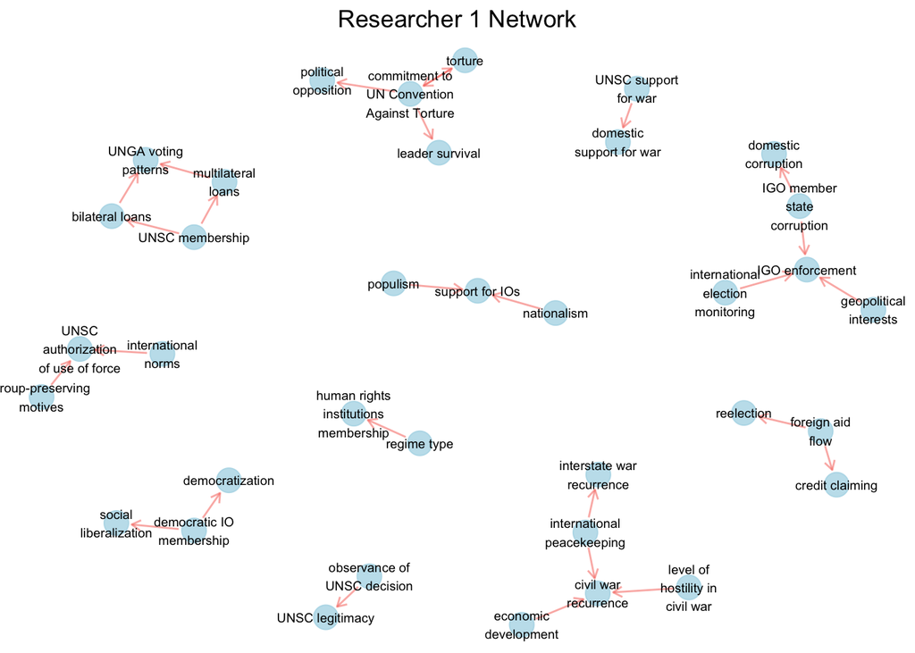

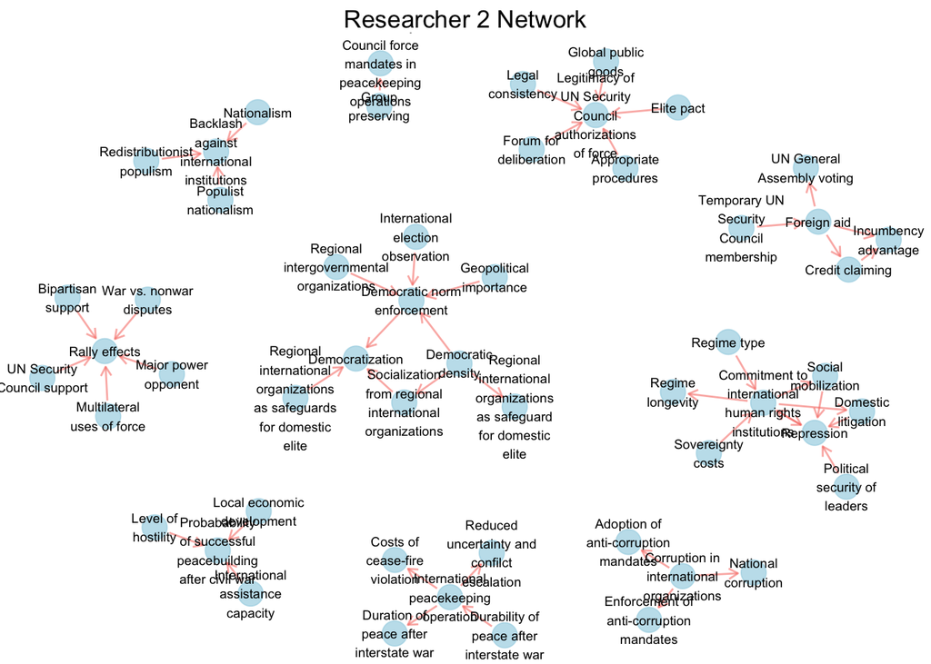

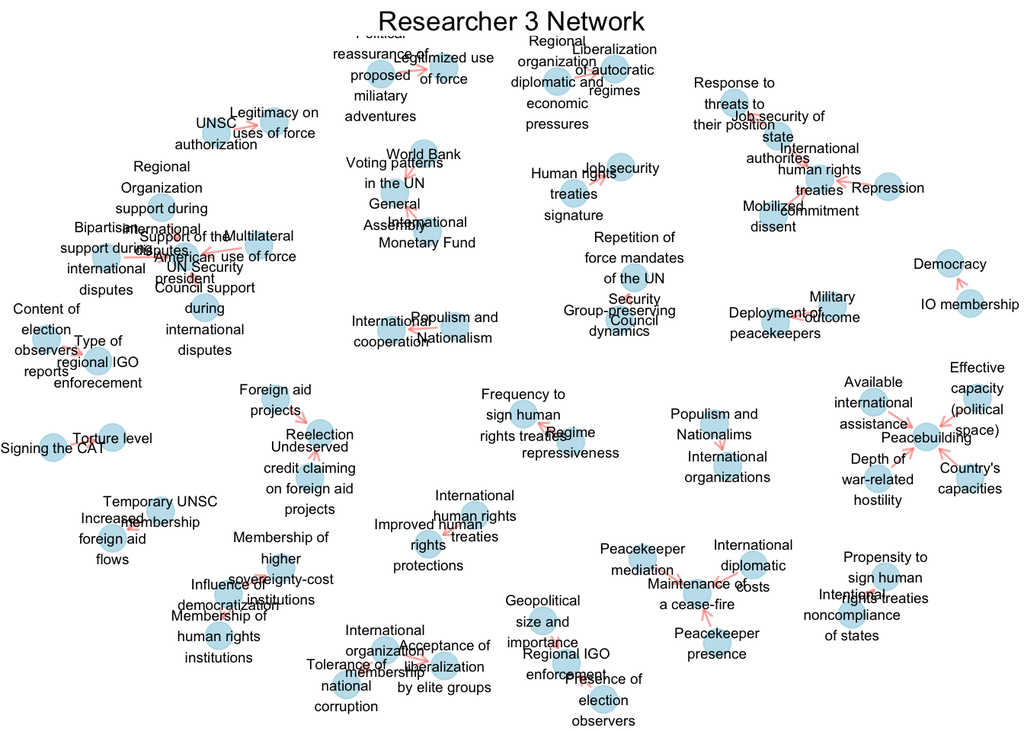

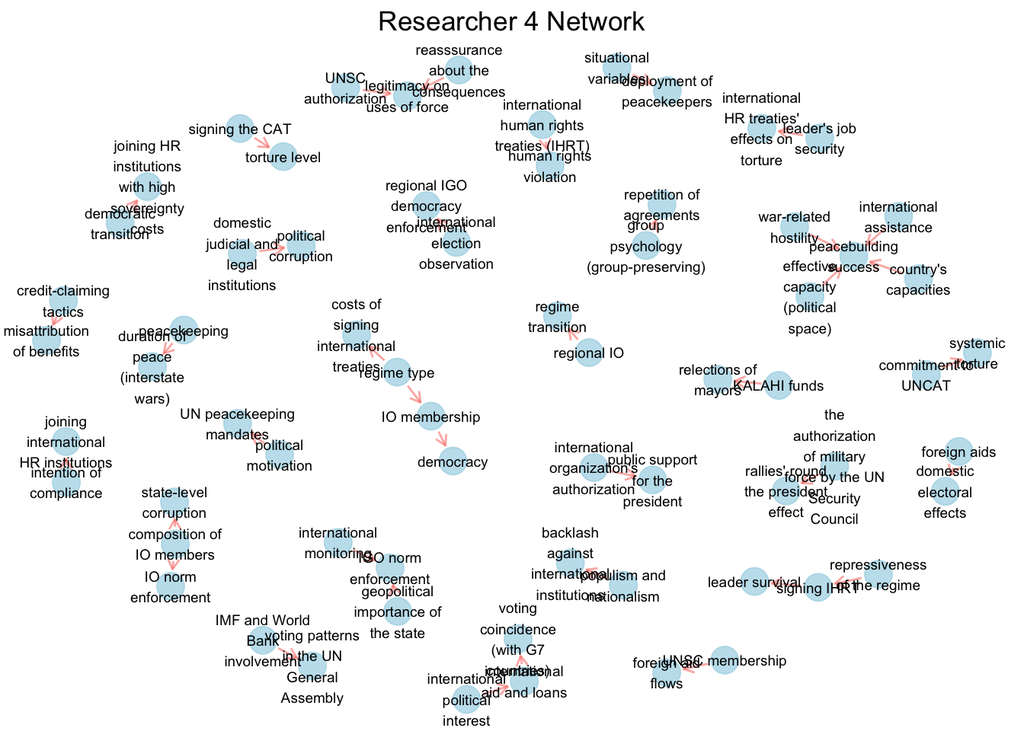

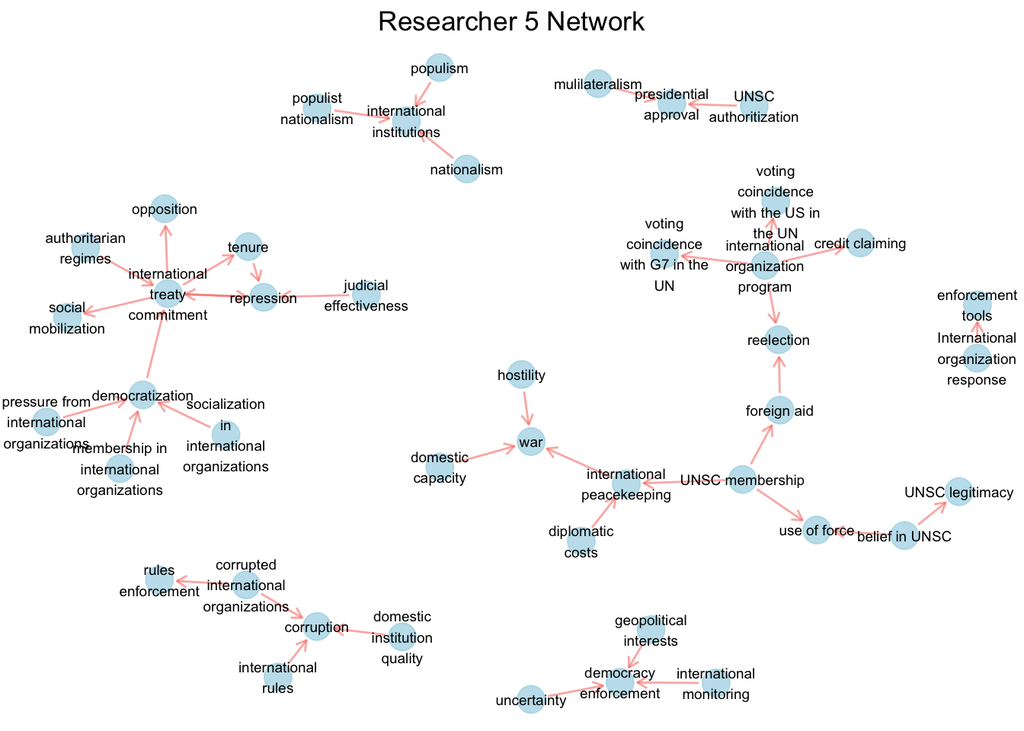